# [RBAC 2024] ROUND 2: CASE STUDY

Our task involves conducting a thorough analysis of the relationships between different customer segments and the loan products they utilize, as well as identifying the key differences and trends that emerged in the years 2022 and 2023. These insights will be essential for understanding customer behavior, market conditions, and their impact on the business during this period.

**As a Business Analyst at SHBFinance, you are required to achieve 5 objectives:**

1. Define customers profile of SHBFinance
2. Define the characteristics of loans borrowed
3. Explore the correlation between customer profile and loans borrowed
4. Compare the year-over-year performance of lending activities
5. Give strategic recommendations to improve loan origination and sales

```python
import pandas as pd
import numpy as np
import matplotlib.pyplot as plt
import seaborn as sns
```

```python
loan_origin = pd.read_csv('dataset/loan_origin.csv')
demographic = pd.read_csv('dataset/demographic.csv')
```

```python
loan_origin.info()
```

```
<class 'pandas.core.frame.DataFrame'>
RangeIndex: 371200 entries, 0 to 371199
Data columns (total 14 columns):
 #   Column                Non-Null Count   Dtype
---  ------                --------------   -----
 0   DISBURSEMENT_CHANNEL  315211 non-null  float64
 1   LIQUIDITY             315574 non-null  float64
 2   INSURANCE_COMPANY     315396 non-null  float64
 3   INSURANCE_RATE        315613 non-null  float64
 4   DISBURSEMENT_DATE     315470 non-null  object
 5   CONTRACT_NO           315643 non-null  float64
 6   RATE                  315635 non-null  float64
 7   HAS_INSURANCE         315334 non-null  object
 8   PRODUCT_CATEGORY      315447 non-null  float64
 9   LOAN_TERM             315169 non-null  float64
 10  MONTH_INTEREST        315292 non-null  float64
 11  LOAN_PURPOSE          315973 non-null  float64
 12  BUSINESS_LINE         315584 non-null  float64
 13  LOAN_AMOUNT           315681 non-null  float64
dtypes: float64(12), object(2)
memory usage: 39.6+ MB
```

```python
demographic.info()
```

```
<class 'pandas.core.frame.DataFrame'>
RangeIndex: 371200 entries, 0 to 371199
Data columns (total 17 columns):
 #   Column                      Non-Null Count   Dtype
---  ------                      --------------   -----
 0   LABOUR_CONTRACT_TYPE        293048 non-null  float64
 1   NUMBER_OF_DEPENDANTS        307877 non-null  float64
 2   PERMANENT_ADDRESS_PROVINCE  315371 non-null  float64
 3   INDUSTRY                    304094 non-null  float64
 4   JOB                         315548 non-null  float64
 5   COMPANY_ADDRESS_PROVINCE    262358 non-null  float64
 6   CONTRACT_NO                 315507 non-null  float64
 7   WEIGHT                      315684 non-null  float64
 8   EDUCATION                   308236 non-null  float64
 9   CUSTOMER_INCOME             315351 non-null  float64
 10  CREDITIBILITY               315533 non-null  float64
 11  ACCOMMODATION_TYPE          307761 non-null  float64
 12  DATE_OF_BIRTH               315328 non-null  float64
 13  HEIGHT                      315411 non-null  float64
 14  WORKING_IN_YEAR             301330 non-null  float64
 15  MARITAL_STATUS              307785 non-null  float64
 16  INCOME_RESOURCE             308138 non-null  float64
dtypes: float64(17)
memory usage: 48.1 MB
```

```python
demographic
```

|  | LABOUR_CONTRACT_TYPE | NUMBER_OF_DEPENDANTS | PERMANENT_ADDRESS_PROVINCE | INDUSTRY | JOB | COMPANY_ADDRESS_PROVINCE | CONTRACT_NO | WEIGHT | EDUCATION | CUSTOMER_INCOME | CREDITIBILITY | ACCOMMODATION_TYPE | DATE_OF_BIRTH | HEIGHT | WORKING_IN_YEAR | MARITAL_STATUS | INCOME_RESOURCE |
| --- | --- | --- | --- | --- | --- | --- | --- | --- | --- | --- | --- | --- | --- | --- | --- | --- | --- |
| 0 | 2.0 | 2.0 | 20.0 | 18.0 | 9.0 | 74.0 | NaN | 60.0 | 1.0 | 6056000.0 | 1.0 | 0.0 | 1979.0 | 155.0 | 1.0 | 2.0 | 5.0 |
| 1 | 4.0 | 0.0 | 58.0 | 18.0 | NaN | 58.0 | 569518.0 | NaN | 2.0 | 19092000.0 | 0.0 | 0.0 | 1969.0 | 178.0 | 2.0 | 1.0 | 1.0 |
| 2 | 4.0 | 0.0 | NaN | 2.0 | NaN | 74.0 | 569723.0 | 65.0 | 1.0 | 1936000.0 | 2.0 | 3.0 | 1964.0 | 189.0 | 16.0 | 4.0 | 5.0 |
| 3 | 4.0 | 1.0 | 46.0 | 18.0 | 4.0 | NaN | NaN | 83.0 | 2.0 | 15413000.0 | 0.0 | 0.0 | NaN | 168.0 | 3.0 | 2.0 | 5.0 |
| 4 | 4.0 | 3.0 | NaN | 18.0 | 9.0 | NaN | 571556.0 | 74.0 | 1.0 | 17533000.0 | 2.0 | NaN | 1974.0 | 172.0 | 8.0 | 2.0 | 5.0 |
| ... | ... | ... | ... | ... | ... | ... | ... | ... | ... | ... | ... | ... | ... | ... | ... | ... | ... |
| 371195 | 4.0 | 3.0 | 75.0 | 18.0 | NaN | 75.0 | 630947.0 | 82.0 | 6.0 | 19262000.0 | 3.0 | 0.0 | 1976.0 | 156.0 | 2.0 | 2.0 | NaN |
| 371196 | 4.0 | 0.0 | 94.0 | NaN | 1.0 | NaN | 823371.0 | 99.0 | NaN | 17533000.0 | NaN | 4.0 | NaN | 175.0 | NaN | 0.0 | 5.0 |
| 371197 | NaN | NaN | 75.0 | 18.0 | NaN | 75.0 | 631768.0 | 63.0 | 3.0 | 12520000.0 | 0.0 | 0.0 | 1994.0 | 141.0 | 3.0 | 2.0 | 5.0 |
| 371198 | 4.0 | 0.0 | 45.0 | 18.0 | NaN | NaN | NaN | 97.0 | NaN | 17533000.0 | 3.0 | 0.0 | 1981.0 | 189.0 | NaN | 2.0 | 1.0 |
| 371199 | 4.0 | NaN | 89.0 | 6.0 | 6.0 | 75.0 | 631333.0 | 69.0 | 1.0 | 19183000.0 | 0.0 | NaN | NaN | 142.0 | 7.0 | NaN | 1.0 |

371200 rows × 17 columns

```python
loan_origin
```

|  | DISBURSEMENT_CHANNEL | LIQUIDITY | INSURANCE_COMPANY | INSURANCE_RATE | DISBURSEMENT_DATE | CONTRACT_NO | RATE | HAS_INSURANCE | PRODUCT_CATEGORY | LOAN_TERM | MONTH_INTEREST | LOAN_PURPOSE | BUSINESS_LINE | LOAN_AMOUNT |
| --- | --- | --- | --- | --- | --- | --- | --- | --- | --- | --- | --- | --- | --- | --- |
| 0 | 1.0 | 3.0 | 0.0 | 3.75 | 2023-09 | 571094.0 | 3.0 | NaN | 0.0 | 36.0 | 2.0 | 1.0 | NaN | 3450000.0 |
| 1 | 2.0 | 3.0 | NaN | 3.75 | 2023-09 | 569518.0 | 4.0 | YES | 1.0 | NaN | 2.6 | 3.0 | 0.0 | 3060000.0 |
| 2 | 1.0 | 1.0 | 0.0 | 3.75 | 2023-09 | 569723.0 | NaN | NaN | 0.0 | NaN | 1.7 | 3.0 | 0.0 | 1520000.0 |
| 3 | 1.0 | 4.0 | 1.0 | 3.75 | 2023-09 | 569501.0 | 0.0 | YES | 1.0 | 15.0 | 2.0 | 3.0 | 0.0 | NaN |
| 4 | 1.0 | 4.0 | 1.0 | 3.75 | 2023-09 | NaN | 2.0 | NaN | 0.0 | NaN | 1.7 | 3.0 | 0.0 | 3060000.0 |
| ... | ... | ... | ... | ... | ... | ... | ... | ... | ... | ... | ... | ... | ... | ... |
| 371195 | 1.0 | 1.0 | 1.0 | 3.75 | 2023-12 | 630947.0 | 5.0 | YES | 2.0 | 36.0 | 1.7 | 3.0 | 2.0 | NaN |
| 371196 | 1.0 | 4.0 | 0.0 | 3.75 | 2023-12 | 823371.0 | 3.0 | YES | 1.0 | 36.0 | NaN | 6.0 | 0.0 | 3060000.0 |
| 371197 | 1.0 | NaN | 0.0 | 3.75 | 2023-12 | NaN | 0.0 | NaN | 2.0 | 18.0 | 2.3 | 6.0 | NaN | 1520000.0 |
| 371198 | 1.0 | 0.0 | 1.0 | NaN | 2023-12 | 630638.0 | NaN | YES | 1.0 | 24.0 | 2.0 | 3.0 | NaN | 1520000.0 |
| 371199 | 1.0 | 0.0 | 0.0 | 3.75 | 2023-12 | 631333.0 | 4.0 | YES | 2.0 | 36.0 | 3.2 | 3.0 | NaN | 3600000.0 |

371200 rows × 14 columns

## DATA PREPARATION

```python
loan_origin.dropna(inplace=True)
loan_origin.info()
```

```
<class 'pandas.core.frame.DataFrame'>
Index: 37902 entries, 14 to 371189
Data columns (total 14 columns):
 #   Column                Non-Null Count  Dtype
---  ------                --------------  -----
 0   DISBURSEMENT_CHANNEL  37902 non-null  float64
 1   LIQUIDITY             37902 non-null  float64
 2   INSURANCE_COMPANY     37902 non-null  float64
 3   INSURANCE_RATE        37902 non-null  float64
 4   DISBURSEMENT_DATE     37902 non-null  object
 5   CONTRACT_NO           37902 non-null  float64
 6   RATE                  37902 non-null  float64
 7   HAS_INSURANCE         37902 non-null  object
 8   PRODUCT_CATEGORY      37902 non-null  float64
 9   LOAN_TERM             37902 non-null  float64
 10  MONTH_INTEREST        37902 non-null  float64
 11  LOAN_PURPOSE          37902 non-null  float64
 12  BUSINESS_LINE         37902 non-null  float64
 13  LOAN_AMOUNT           37902 non-null  float64
dtypes: float64(12), object(2)
memory usage: 4.3+ MB
```

```python
demographic.dropna(inplace=True)
demographic.info()
```

```
<class 'pandas.core.frame.DataFrame'>
Index: 18857 entries, 19 to 371187
Data columns (total 17 columns):
 #   Column                      Non-Null Count  Dtype
---  ------                      --------------  -----
 0   LABOUR_CONTRACT_TYPE        18857 non-null  float64
 1   NUMBER_OF_DEPENDANTS        18857 non-null  float64
 2   PERMANENT_ADDRESS_PROVINCE  18857 non-null  float64
 3   INDUSTRY                    18857 non-null  float64
 4   JOB                         18857 non-null  float64
 5   COMPANY_ADDRESS_PROVINCE    18857 non-null  float64
 6   CONTRACT_NO                 18857 non-null  float64
 7   WEIGHT                      18857 non-null  float64
 8   EDUCATION                   18857 non-null  float64
 9   CUSTOMER_INCOME             18857 non-null  float64
 10  CREDITIBILITY               18857 non-null  float64
 11  ACCOMMODATION_TYPE          18857 non-null  float64
 12  DATE_OF_BIRTH               18857 non-null  float64
 13  HEIGHT                      18857 non-null  float64
 14  WORKING_IN_YEAR             18857 non-null  float64
 15  MARITAL_STATUS              18857 non-null  float64
 16  INCOME_RESOURCE             18857 non-null  float64
dtypes: float64(17)
memory usage: 2.6 MB
```

```python
merged_df = pd.merge(demographic, loan_origin, on='CONTRACT_NO', how='inner')
# Scale the income and loan amount to millions (unit: 1,000,000 VND)
merged_df['CUSTOMER_INCOME'] = merged_df['CUSTOMER_INCOME'] / 1e6
merged_df['LOAN_AMOUNT'] = merged_df['LOAN_AMOUNT'] / 1e6
merged_df
```

|  | LABOUR_CONTRACT_TYPE | NUMBER_OF_DEPENDANTS | PERMANENT_ADDRESS_PROVINCE | INDUSTRY | JOB | COMPANY_ADDRESS_PROVINCE | CONTRACT_NO | WEIGHT | EDUCATION | CUSTOMER_INCOME | ... | INSURANCE_RATE | DISBURSEMENT_DATE | RATE | HAS_INSURANCE | PRODUCT_CATEGORY | LOAN_TERM | MONTH_INTEREST | LOAN_PURPOSE | BUSINESS_LINE | LOAN_AMOUNT |
| --- | --- | --- | --- | --- | --- | --- | --- | --- | --- | --- | --- | --- | --- | --- | --- | --- | --- | --- | --- | --- | --- |
| 0 | 4.0 | 0.0 | 89.0 | 18.0 | 9.0 | 74.0 | 572766.0 | 71.0 | 3.0 | 15.413 | ... | 3.75 | 2023-09 | 0.0 | YES | 1.0 | 24.0 | 2.6 | 1.0 | 0.0 | 3.06 |
| 1 | 4.0 | 1.0 | 80.0 | 18.0 | 4.0 | 80.0 | 406966.0 | 54.0 | 3.0 | 18.288 | ... | 3.00 | 2022-08 | 1.0 | YES | 1.0 | 15.0 | 2.2 | 3.0 | 0.0 | 1.47 |
| 2 | 4.0 | 0.0 | 48.0 | 18.0 | 9.0 | 48.0 | 410391.0 | 56.0 | 1.0 | 9.747 | ... | 3.00 | 2022-08 | 2.0 | YES | 1.0 | 24.0 | 2.2 | 6.0 | 0.0 | 1.47 |
| 3 | 2.0 | 2.0 | 14.0 | 18.0 | 9.0 | 33.0 | 411248.0 | 73.0 | 1.0 | 6.351 | ... | 3.00 | 2022-08 | 0.0 | YES | 0.0 | 24.0 | 2.5 | 3.0 | 0.0 | 1.47 |
| 4 | 4.0 | 0.0 | 72.0 | 18.0 | 1.0 | 72.0 | 773890.0 | 72.0 | 1.0 | 16.355 | ... | 3.00 | 2022-08 | 3.0 | YES | 11.0 | 18.0 | 2.7 | 6.0 | 0.0 | 1.47 |
| ... | ... | ... | ... | ... | ... | ... | ... | ... | ... | ... | ... | ... | ... | ... | ... | ... | ... | ... | ... | ... | ... |
| 1874 | 4.0 | 1.0 | 37.0 | 18.0 | 9.0 | 37.0 | 626892.0 | 98.0 | 0.0 | 18.808 | ... | 3.75 | 2023-12 | 1.0 | YES | 1.0 | 24.0 | 2.6 | 1.0 | 2.0 | 3.06 |
| 1875 | 4.0 | 0.0 | 31.0 | 18.0 | 9.0 | 74.0 | 628683.0 | 84.0 | 1.0 | 16.355 | ... | 3.75 | 2023-12 | 2.0 | YES | 5.0 | 24.0 | 0.9 | 1.0 | 2.0 | 3.06 |
| 1876 | 4.0 | 0.0 | 51.0 | 18.0 | 7.0 | 51.0 | 631435.0 | 69.0 | 2.0 | 19.092 | ... | 3.75 | 2023-12 | 5.0 | YES | 1.0 | 36.0 | 1.7 | 3.0 | 2.0 | 4.06 |
| 1877 | 4.0 | 0.0 | 91.0 | 18.0 | 6.0 | 91.0 | 630694.0 | 65.0 | 6.0 | 15.413 | ... | 3.75 | 2023-12 | 4.0 | YES | 1.0 | 18.0 | 2.0 | 3.0 | 2.0 | 1.52 |
| 1878 | 4.0 | 2.0 | 1.0 | 14.0 | 7.0 | 1.0 | 823324.0 | 59.0 | 2.0 | 18.808 | ... | 3.75 | 2023-12 | 5.0 | YES | 1.0 | 18.0 | 1.7 | 3.0 | 0.0 | 3.06 |

1879 rows × 30 columns

```python
merged_df['YEAR'] = [x.split('-')[0] for x in merged_df['DISBURSEMENT_DATE']]
merged_2022 = merged_df[merged_df['YEAR'] == '2022']
merged_2022.Name = 2022
merged_2023 = merged_df[merged_df['YEAR'] == '2023']
merged_2023.Name = 2023
```

```python
colors = ['#FF0000', '#FF8700', '#FFD300', '#A1FF0A',
          '#0AFF99', '#0AEFFF', '#147DF5', '#BE0AFF']


def hist_plot(df, attr, colors, bin_size=1):
    min_value = df[attr].min()
    max_value = df[attr].max()
    bins = np.arange(min_value, max_value + bin_size * 2, bin_size)

    plt.figure(figsize=(22, 6))

    counts, bins, patches = plt.hist(df[attr], bins=bins, edgecolor='black')
    plt.xticks(bins, rotation=60)

    for count, patch in zip(counts, patches):
        plt.text(patch.get_x() + patch.get_width() / 2, count, int(count),
                 ha='center', va='bottom')

    for i, patch in enumerate(patches):
        patch.set_facecolor(colors[i % len(colors)])

    plt.xlabel(attr)
    plt.ylabel('Count')
    if hasattr(df, 'Name'):
        plt.title(f'Histogram Plot for {attr} of {df.Name}')
    else:
        plt.title(f'Histogram Plot for {attr}')


def hist_plot_1(df, attr, colors, bin_size=1):
    max_value = df[attr].max()
    # Tạo bins với khoảng cách 1 triệu
    bins = np.arange(0, max_value + bin_size, bin_size)

    plt.figure(figsize=(22, 6))
    counts, bins, patches = plt.hist(df[attr], bins=bins, edgecolor='black')

    labels = [f'{int(x)}M' for x in bins]
    plt.xticks(bins, labels, rotation=60)

    for count, patch in zip(counts, patches):
        plt.text(patch.get_x() + patch.get_width() / 2, count, int(count),
                 ha='center', va='bottom')

    for i, patch in enumerate(patches):
        patch.set_facecolor(colors[i % len(colors)])

    plt.xlabel(attr)
    plt.ylabel('Count')

    if hasattr(df, 'Name'):
        plt.title(f'Histogram Plot for {attr} of {df.Name}')
    else:
        plt.title(f'Histogram Plot for {attr}')

def pie_plot(df, attr, colors):
    counts = df[attr].value_counts()
    labels = counts.index.tolist()
    values = counts.values.tolist()

    colors = [colors[i % len(colors)] for i in range(len(labels))]

    plt.figure(figsize=(8, 8))
    wedges, texts = plt.pie(values, startangle=90, colors=colors, wedgeprops={
                            'edgecolor': 'black'}, labels=['']*len(values))

    legend_labels = [f'{label}: {value} ({percentage:.1f}%)' for label, value, percentage in zip(
        labels, values, [100 * v / sum(values) for v in values])]

    plt.legend(wedges, legend_labels, title=attr,
               loc="center left", bbox_to_anchor=(1, 0, 0.5, 1))

    if hasattr(df, 'Name'):
        plt.title(f'Pie Chart for {attr} of {df.Name}')
    else:
        plt.title(f'Pie Chart for {attr}')


def pie_plot_1(df, attr, colors):
    counts = df[attr].value_counts()
    labels_tmp = counts.index.tolist()
    values_tmp = counts.values.tolist()
    # print(counts)

    labels = labels_tmp[:3]
    values = values_tmp[:3]
    labels.append('Greater than 2')
    values.append(sum(values_tmp[3:]))

    colors = [colors[i % len(colors)] for i in range(len(labels))]

    plt.figure(figsize=(8, 8))
    wedges, texts, autotexts = plt.pie(
        values, autopct='%1.1f%%', startangle=90, colors=colors, wedgeprops={'edgecolor': 'black'})

    plt.legend(wedges, labels, title=attr, loc="center left",
               bbox_to_anchor=(1, 0, 0.5, 1))

    if hasattr(df, 'Name'):
        plt.title(f'Pie Chart for {attr} of {df.Name}')
    else:
        plt.title(f'Pie Chart for {attr}')

def box_plot(df, attr, colors):
    plt.figure(figsize=(22, 6))
    box = df.boxplot(column=attr, grid=False, vert=False, patch_artist=True, color=dict(boxes='blue', whiskers='black', medians='black', caps='black'))

    # Get the data for the specified attribute
    data = df[attr].dropna()  # Drop any NaN values

    # Calculate the first quartile (Q1) and third quartile (Q3)
    Q1 = data.quantile(0.25)
    Q3 = data.quantile(0.75)
    IQR = Q3 - Q1

    # Define the outlier thresholds
    lower_bound = Q1 - 1.5 * IQR
    upper_bound = Q3 + 1.5 * IQR

    # Find outliers
    outliers = data[(data < lower_bound) | (data > upper_bound)]

    # Plot outliers with their values
    for outlier in outliers:
        plt.text(outlier, 1, f'{outlier}', ha='center', va='top', color='red', rotation=60)

    plt.xlabel(attr)
    if hasattr(df, 'Name') and df.Name:
        plt.title(f'Box Plot for {attr} of {df.Name}')
    else:
        plt.title(f'Box Plot for {attr}')

# def bar_plot(df, attr, colors):
#     counts = df[attr].value_counts()
#     labels = counts.index.tolist()
#     values = counts.values.tolist()

#     plt.figure(figsize=(22, 6))

#     bars = plt.bar(labels, values, edgecolor='black', color=[colors[i % len(colors)] for i in range(len(labels))])

#     plt.xticks(rotation=60)
#     plt.xlabel(attr)
#     plt.ylabel('Count')
#     if df.Name:
#         plt.title(f'Bar Plot for {attr} of {df.Name}')
#     else:
#         plt.title(f'Bar Plot for {attr}')

#     for bar, count in zip(bars, values):
#         plt.text(bar.get_x() + bar.get_width() / 2, bar.get_height(), int(count),
#                  ha='center', va='bottom')
```

## QUESTION 1:

SHBFinance wants to learn more about their customers. Could you provide a detailed description of the demographics of customers who borrowed loans in 2022 and 2023?.

### YEAR_OF_BIRTH

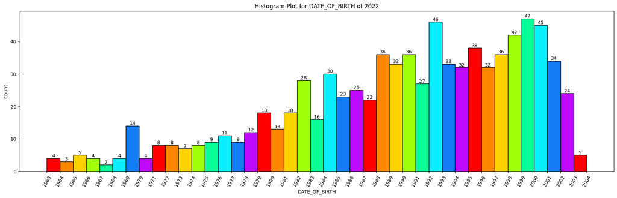

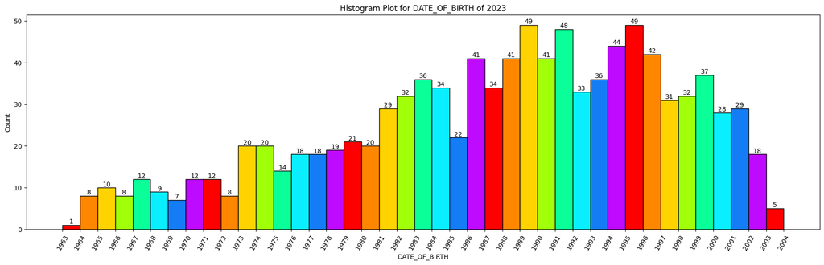

```python
hist_plot(merged_2022, 'DATE_OF_BIRTH', colors)
hist_plot(merged_2023, 'DATE_OF_BIRTH', colors)
```

### NUMBER_OF_DEPENDANTS

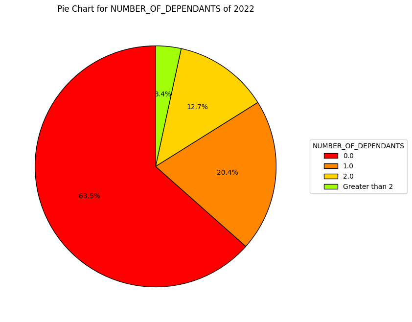

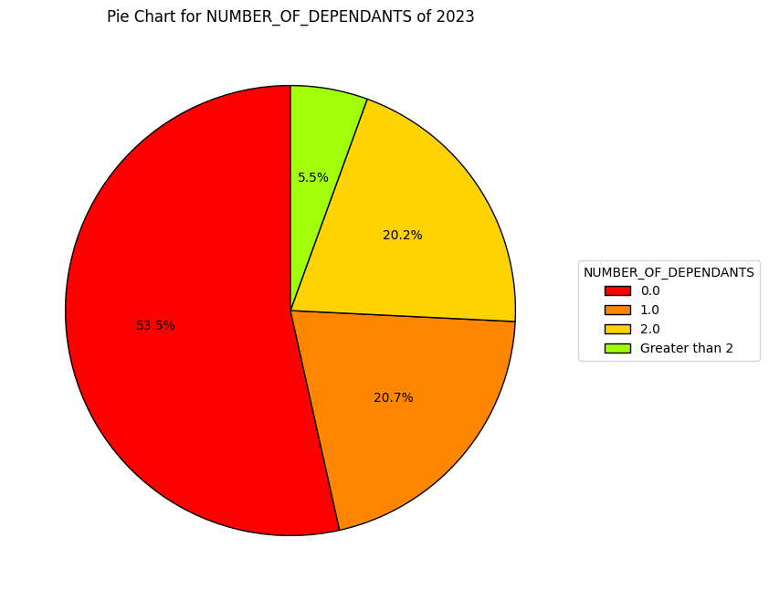

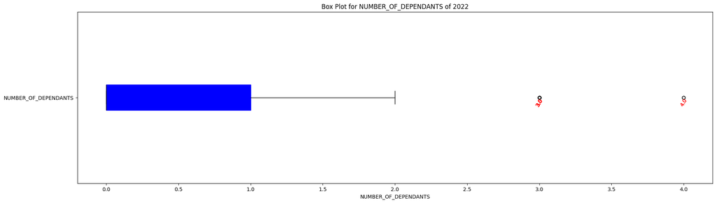

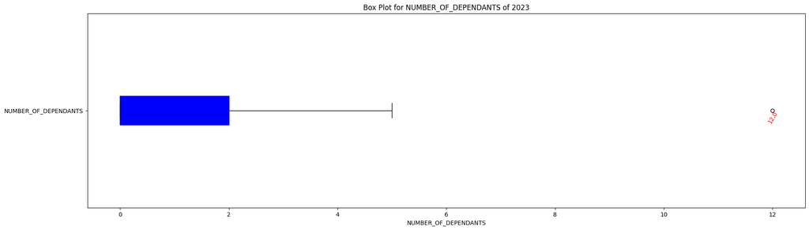

```python
pie_plot_1(merged_2022, 'NUMBER_OF_DEPENDANTS', colors)
pie_plot_1(merged_2023, 'NUMBER_OF_DEPENDANTS', colors)

box_plot(merged_2022, 'NUMBER_OF_DEPENDANTS', colors)
box_plot(merged_2023, 'NUMBER_OF_DEPENDANTS', colors)
```

### CUSTOMER_INCOME

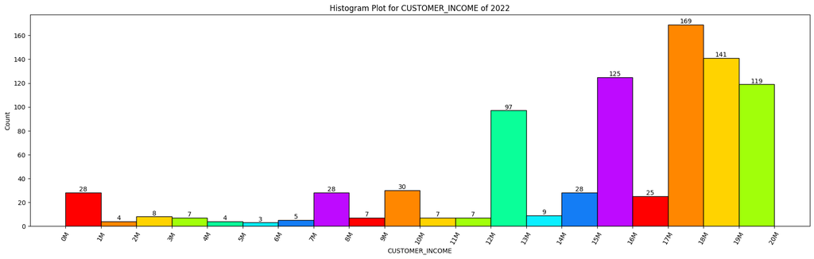

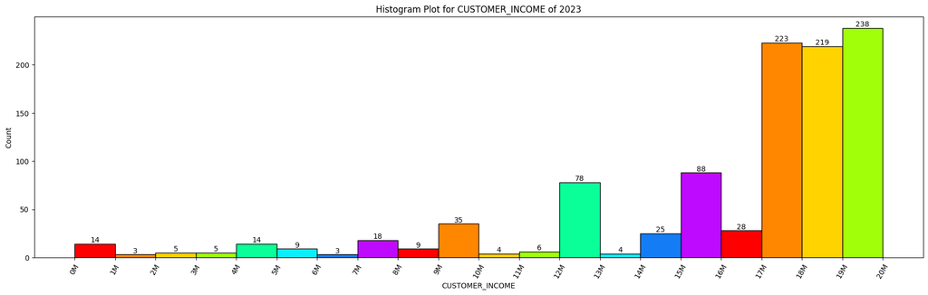

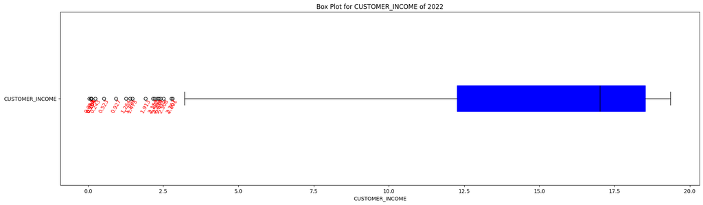

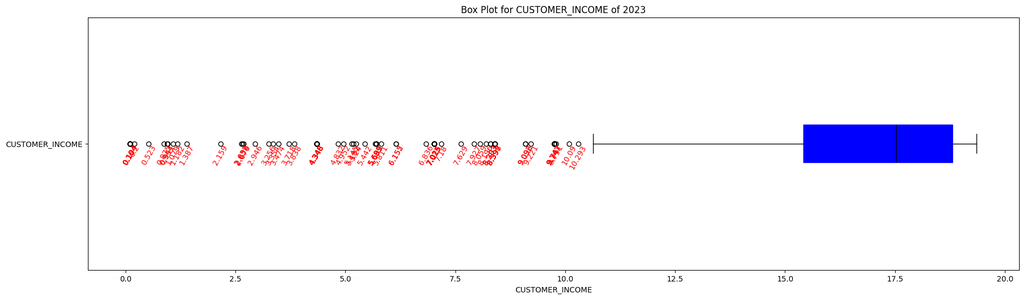

```python
hist_plot_1(merged_2022, 'CUSTOMER_INCOME', colors)
hist_plot_1(merged_2023, 'CUSTOMER_INCOME', colors)

box_plot(merged_2022, 'CUSTOMER_INCOME', colors)
box_plot(merged_2023, 'CUSTOMER_INCOME', colors)
```

### WORKING_IN_YEAR

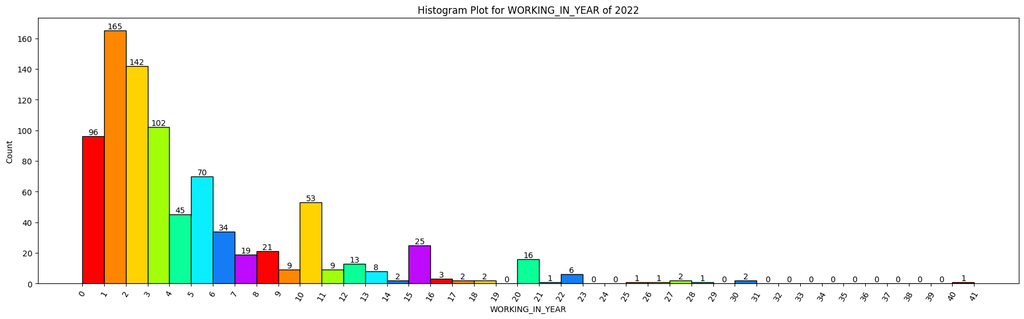

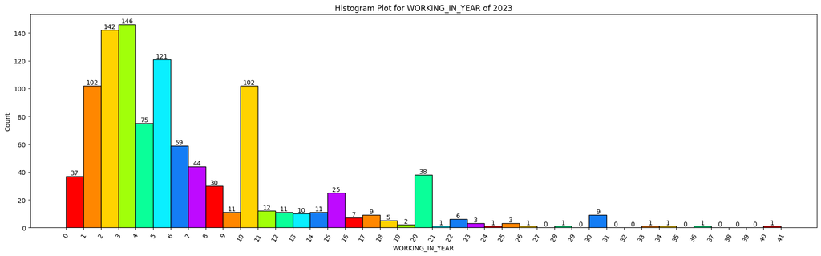

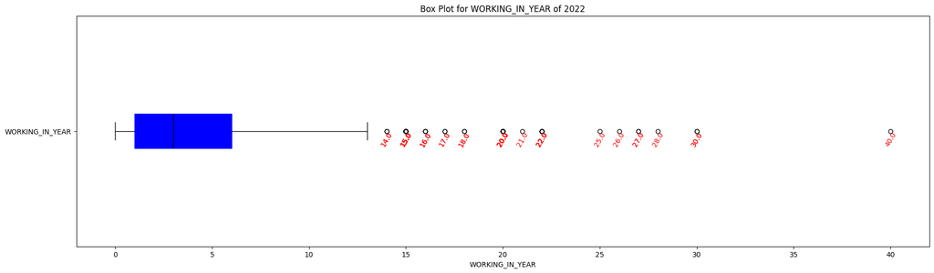

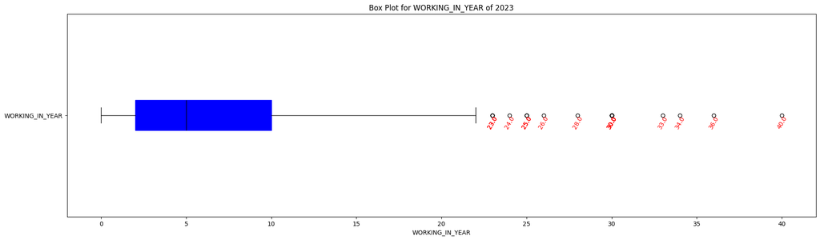

```python
hist_plot(merged_2022, 'WORKING_IN_YEAR', colors)
hist_plot(merged_2023, 'WORKING_IN_YEAR', colors)

box_plot(merged_2022, 'WORKING_IN_YEAR', colors)
box_plot(merged_2023, 'WORKING_IN_YEAR', colors)
```

## QUESTION 2:

Examine the loans borrowed in detailed, including:

- Loan Types
- Amount Borrowed
- Interest Rate
- Loan Purposes
- Loan Terms
- Other Factors (if possible)

```python
Q2 = merged_df[['PRODUCT_CATEGORY', 'LOAN_AMOUNT', 'MONTH_INTEREST', 'LOAN_PURPOSE', 'LOAN_TERM']]
Q2.describe()
```

|  | PRODUCT_CATEGORY | LOAN_AMOUNT | MONTH_INTEREST | LOAN_PURPOSE | LOAN_TERM |
| --- | --- | --- | --- | --- | --- |
| count | 1879.000000 | 1879.000000 | 1879.000000 | 1879.000000 | 1879.000000 |
| mean | 1.758914 | 2.588771 | 2.036935 | 3.718467 | 25.526344 |
| std | 2.143145 | 1.580305 | 0.578123 | 1.609356 | 8.542023 |
| min | 0.000000 | 0.270000 | 0.400000 | 1.000000 | 9.000000 |
| 25% | 1.000000 | 1.470000 | 1.700000 | 3.000000 | 18.000000 |
| 50% | 1.000000 | 2.710000 | 2.200000 | 3.000000 | 24.000000 |
| 75% | 2.000000 | 3.940000 | 2.500000 | 6.000000 | 36.000000 |
| max | 15.000000 | 6.390000 | 3.200000 | 6.000000 | 36.000000 |

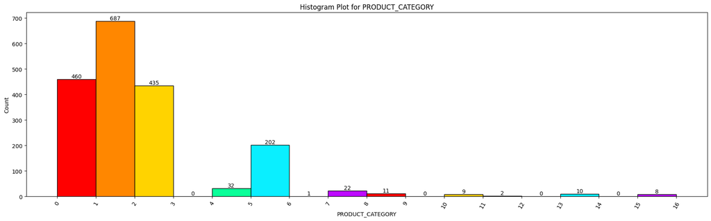

```python
hist_plot(Q2, 'PRODUCT_CATEGORY', colors)
```

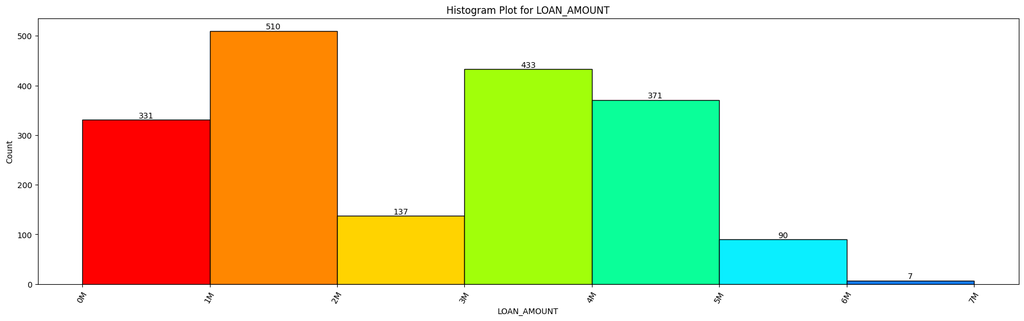

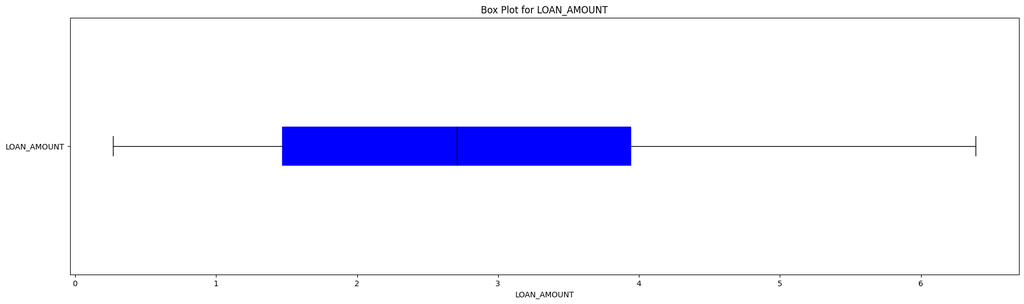

```python
hist_plot_1(Q2, 'LOAN_AMOUNT', colors)
box_plot(Q2, 'LOAN_AMOUNT', colors)
```

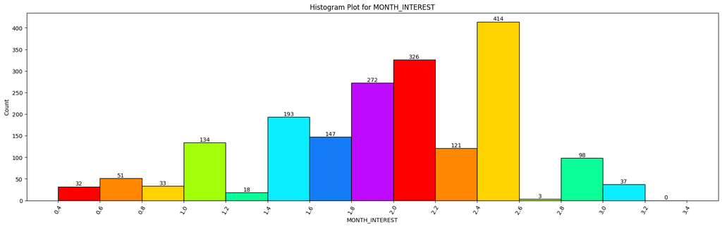

```python
hist_plot(Q2, 'MONTH_INTEREST', colors, 0.2)
```

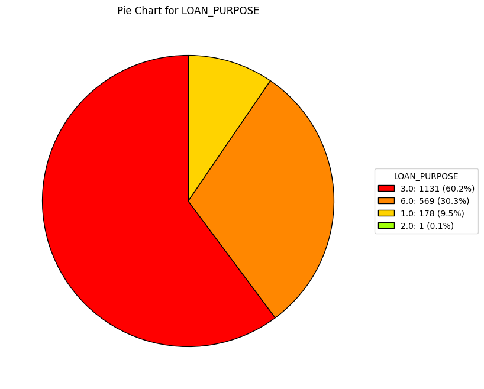

```python
pie_plot(Q2, 'LOAN_PURPOSE', colors)
```

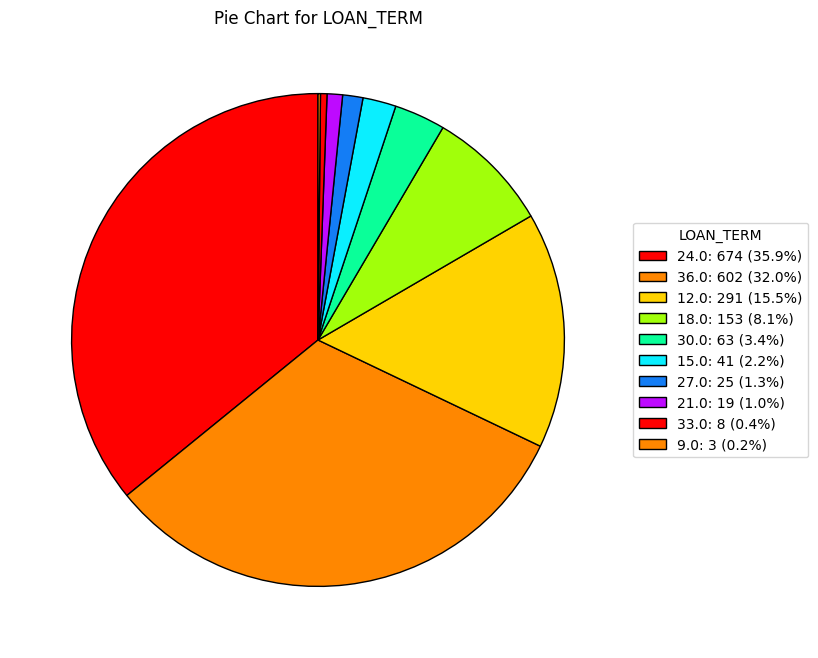

```python
pie_plot(Q2, 'LOAN_TERM', colors)
```

## QUESTION 3:

Finding the relationship between customer profiles and loan types is significant for risk management and improving services.

- Can you explore the relationship between customer demographics and the types of loans they borrowed? Are there any significant correlations and patterns?
- Are there any differences in trends or customer behaviour between 2022 and 2023?

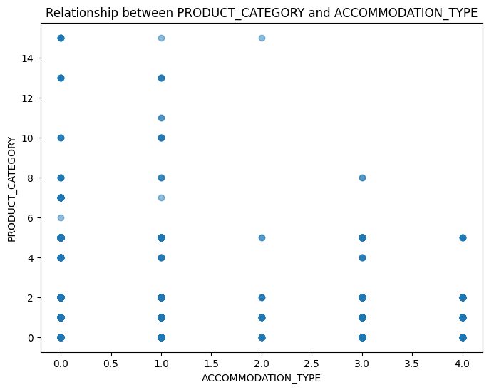

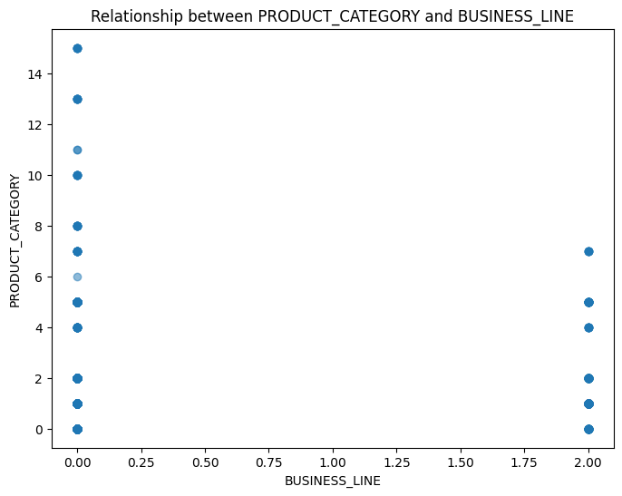

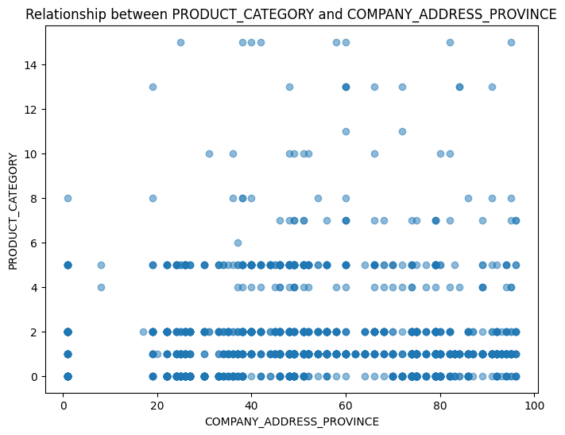

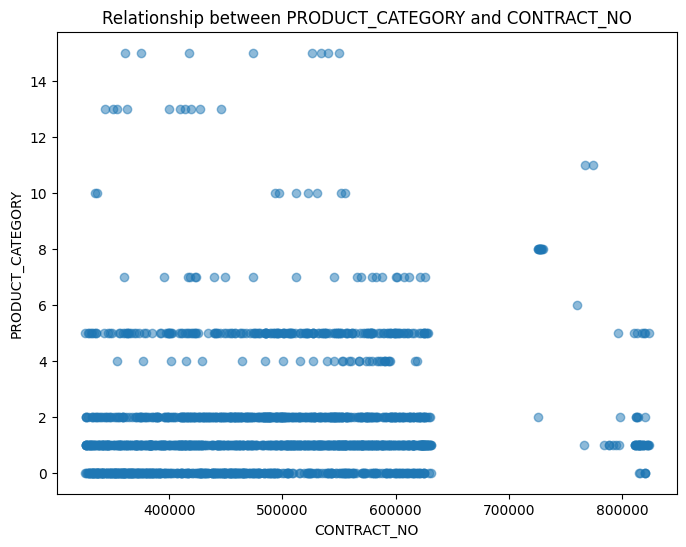

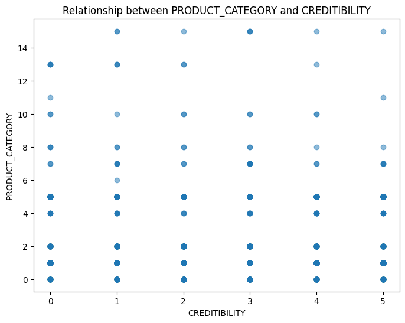

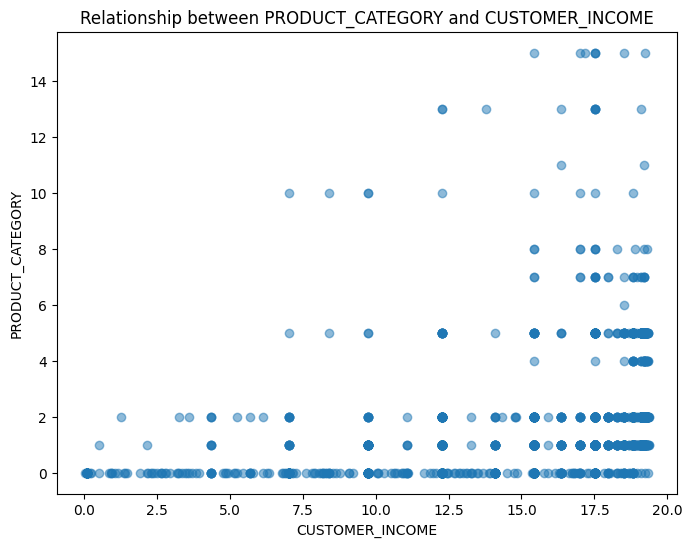

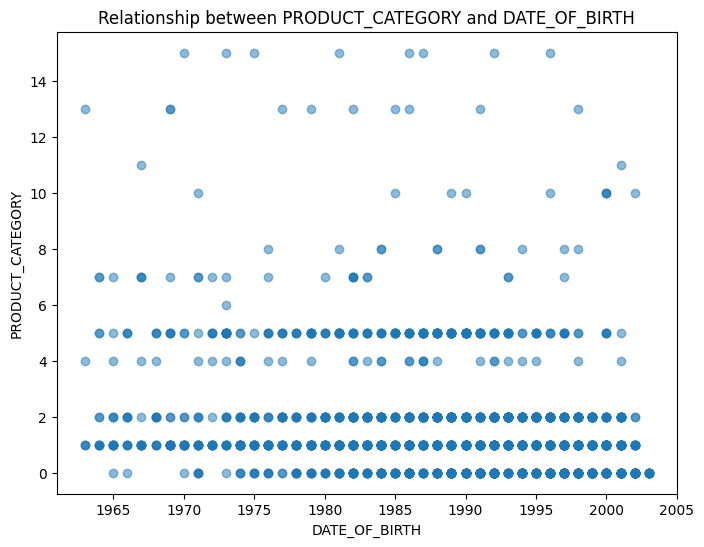

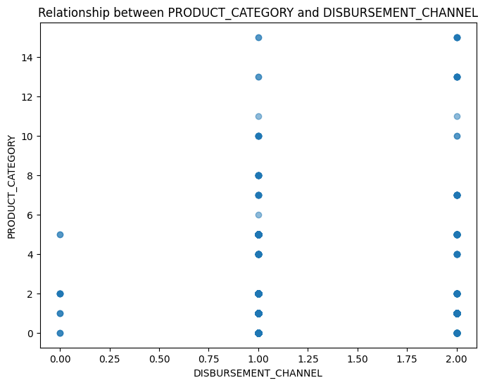

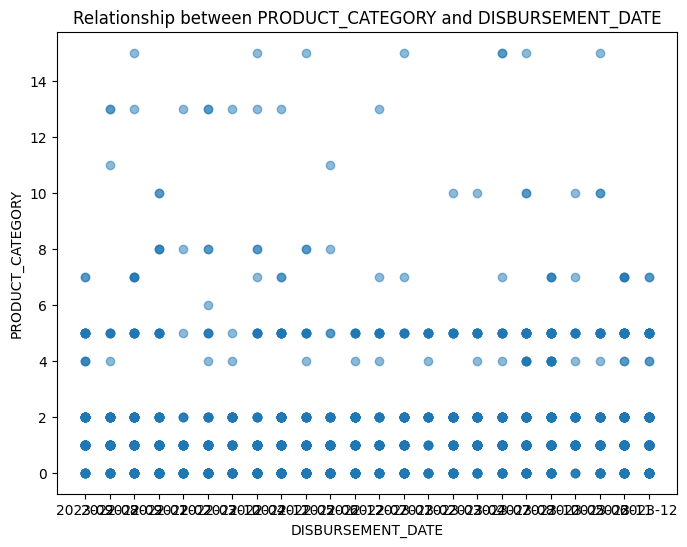

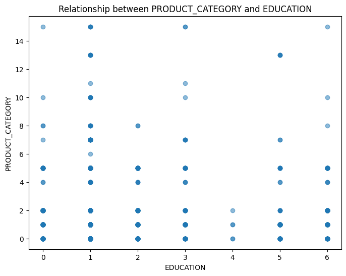

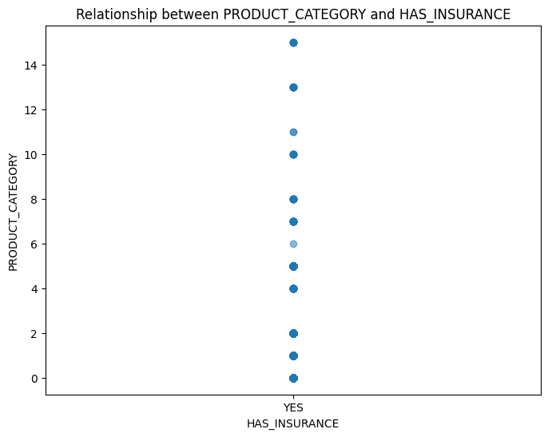

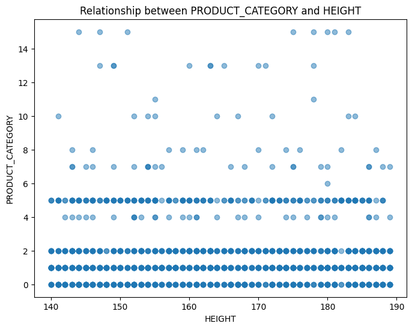

[18 more figures not shown]

```python
def plot_relationships(df, target_attr):
    other_attrs = df.columns.difference([target_attr])

    for attr in other_attrs:
        plt.figure(figsize=(8, 6))
        plt.scatter(df[attr], df[target_attr], alpha=0.5)
        plt.xlabel(attr)
        plt.ylabel(target_attr)
        plt.title(f'Relationship between {target_attr} and {attr}')
        plt.show()

# Example usage
plot_relationships(merged_df, 'PRODUCT_CATEGORY')
```

## QUESTION 4:

From the above analysis, can you develop actionable insights and recommendations to increase loan origination and sales based on the findings from the analysis? Focus on identifying new opportunities and strategies to target potential customers effectively